# zhang_reddit_assignment

2025-04-17

# Search for URLs

### Combining keywords search within the subreddit

```r
top_vas_urls <- find_thread_urls(subreddit="abortion", keywords = "vasectomy", sort_by="top")
```

```
## parsing URLs on page 1...
```

```r
str(top_vas_urls)
```

```
## 'data.frame':    5 obs. of  7 variables:
##  $ date_utc : chr  "2025-04-09" "2025-04-12" "2025-04-08" "2025-03-26" ...
##  $ timestamp: num  1.74e+09 1.74e+09 1.74e+09 1.74e+09 1.74e+09
##  $ title    : chr  "Absolutely devastated but I know what I have to do" "Loneliness in my decision, please someone talk to me" "MA at 6 weeks - not to bad!" "SA and venting/reassurance" ...
##  $ text     : chr  "My husband has been rescheduled for a vasectomy 3 times in the past 5 months and we have been using condoms in "| __truncated__ "I don't want to do this. I'm a married mom of 2 and my husband doesn't want anymore children. He also wants to "| __truncated__ "Hey everyone! I pro…
##  $ subreddit: chr  "abortion" "abortion" "abortion" "abortion" ...
##  $ comments : num  19 6 2 3 3
##  $ url      : chr  "https://www.reddit.com/r/abortion/comments/1jvb13i/absolutely_devastated_but_i_know_what_i_have_to_do/" "https://www.reddit.com/r/abortion/comments/1jxjto2/loneliness_in_my_decision_please_someone_talk_to/" "https://www.reddit.com/r/abortion/comments/1jubylz/ma_at_6_weeks_not_…
```

#subreddit url search

```r
top_abort_urls <- find_thread_urls(subreddit="abortion", sort_by="top")
```

```
## parsing URLs on page 1...
## parsing URLs on page 2...
## parsing URLs on page 3...
## parsing URLs on page 4...
## parsing URLs on page 5...
## parsing URLs on page 6...
## parsing URLs on page 7...
## parsing URLs on page 8...
## parsing URLs on page 9...
## parsing URLs on page 10...
```

```r
str(top_abort_urls)
```

```
## 'data.frame':    992 obs. of  7 variables:
##  $ date_utc : chr  "2025-04-06" "2025-04-06" "2025-04-06" "2025-04-06" ...
##  $ timestamp: num  1.74e+09 1.74e+09 1.74e+09 1.74e+09 1.74e+09 ...
##  $ title    : chr  "Need help on an important decision" "I have a question On MA aftercare" "MA Experience 7 weeks" "carafem or aid access??" ...
##  $ text     : chr  "I am grappling with a difficult decision and I want to hear different perspectives. If someone has already had "| __truncated__ "I had a medical abortion on Thursday, I am wondering now if I can switch to tampons since I don\031t usually we"| __truncated__ "Hello, I read so ma…
##  $ subreddit: chr  "abortion" "abortion" "abortion" "abortion" ...
##  $ comments : num  18 2 3 8 4 2 4 1 3 2 ...
##  $ url      : chr  "https://www.reddit.com/r/abortion/comments/1jslmvk/need_help_on_an_important_decision/" "https://www.reddit.com/r/abortion/comments/1jsldzf/i_have_a_question_on_ma_aftercare/" "https://www.reddit.com/r/abortion/comments/1jsl3el/ma_experience_7_weeks/" "https://www.reddit.com/r…
```

# Save the results from 2025.4.17

```r
#write.csv(top_abort_urls,"top_abort_urls_2025417.csv")
top_abort_urls = read.csv("top_abort_urls_2025417.csv")

#write.csv(top_vas_urls,"top_vas_urls_2025417.csv")
top_vas_urls = read.csv("top_vas_urls_2025417.csv")
```

# Tokenize posts and produce a list of the top 20 bigrams

### 1. Tokenize the whole abortion subreddit and produce the list of its top 20 bigram

```r
#Tokenize the text column
abort_text <- str_replace_all(top_abort_urls$text, "- ", "")
abort_text_df <- tibble(abort_text,)

abort_tokenized <- abort_text_df %>%
  unnest_tokens(word,abort_text)

#remove stop words
data(stop_words)
abort_tokenized <- abort_tokenized%>%
  anti_join(stop_words, by = c("word" = "word")) %>%
  filter(word != "temp_file") %>%
  filter(word != "stories_corpus") %>%
  filter(!grepl('[0-9]', word))

bigrams <- abort_text_df %>%
  unnest_tokens(bigram, abort_text, token="ngrams", n=2)

bigrams
```

```
## # A tibble: 220,024 × 1
##    bigram
##    <chr>
##  1 i am
##  2 am grappling
##  3 grappling with
##  4 with a
##  5 a difficult
##  6 difficult decision
##  7 decision and
##  8 and i
##  9 i want
## 10 want to
## # ℹ 220,014 more rows
```

```r
#Filter out stop words.

bigrams1 <- bigrams %>%
  separate(bigram, c("word1", "word2"), sep = " ")

bigrams2 <- bigrams1 %>%
  filter(!word1 %in% stop_words$word) %>%
  filter(!word2 %in% stop_words$word) %>%
  filter(!is.na(word1)) %>%
  filter(!is.na(word2))

# word count and top 20 bigram
bigram3 <- bigrams2 %>%
  count(word1, word2, sort = TRUE)%>%
  top_n(20, n)

bigram3
```

```
## # A tibble: 20 × 3
##    word1     word2          n
##    <chr>     <chr>      <int>
##  1 6         weeks        115
##  2 medical   abortion     104
##  3 weeks     pregnant      83
##  4 5         weeks         80
##  5 birth     control       73
##  6 4         weeks         68
##  7 surgical  abortion      67
##  8 weeks     ago           66
##  9 3         days          60
## 10 30        minutes       57
## 11 planned   parenthood    57
## 12 2         weeks         56
## 13 pregnancy test          56
## 14 days      ago           55
## 15 2         days          54
## 16 8         weeks         52
## 17 9         weeks         49
## 18 blood     clots         49
## 19 7         weeks         48
## 20 3         weeks         46
```

### 2. Tokenize the vasectomy posts in the abortion subreddit and produce the list of its top 20 bigram

```r
#Tokenize the text column
vas_text <- str_replace_all(top_vas_urls$text, "- ", "")
vas_text_df <- tibble(vas_text,)

vas_tokenized <- vas_text_df %>%
  unnest_tokens(word,vas_text)

#remove stop words
data(stop_words)
vas_tokenized <- vas_tokenized%>%
  anti_join(stop_words, by = c("word" = "word")) %>%
  filter(word != "temp_file") %>%
  filter(word != "stories_corpus") %>%
  filter(!grepl('[0-9]', word))

bigrams_vas <- vas_text_df %>%
  unnest_tokens(bigrams_vas, vas_text, token="ngrams", n=2)

bigrams_vas
```

```
## # A tibble: 2,018 × 1
##    bigrams_vas
##    <chr>
##  1 my husband
##  2 husband has
##  3 has been
##  4 been rescheduled
##  5 rescheduled for
##  6 for a
##  7 a vasectomy
##  8 vasectomy 3
##  9 3 times
## 10 times in
## # ℹ 2,008 more rows
```

```r
#Filter out stop words.

bigrams_vas1 <- bigrams_vas %>%
  separate(bigrams_vas, c("word1", "word2"), sep = " ")

bigrams_vas2 <- bigrams_vas1 %>%
  filter(!word1 %in% stop_words$word) %>%
  filter(!word2 %in% stop_words$word) %>%
  filter(!is.na(word1)) %>%
  filter(!is.na(word2))

# word count and top 20 bigram
bigrams_vas3 <- bigrams_vas2 %>%
  count(word1, word2, sort = TRUE)%>%
  top_n(20, n)

bigrams_vas3
```

```
## # A tibble: 120 × 3
##    word1     word2          n
##    <chr>     <chr>      <int>
##  1 surgical  abortion       3
##  2 pregnancy terminated     2
##  3 1         10             1
##  4 2         days           1
##  5 2         hours          1
##  6 2         pm             1
##  7 27        afab           1
##  8 3         amp            1
##  9 3         times          1
## 10 30        mins           1
## # ℹ 110 more rows
```

# Filter weeks, days, minutes, and hours for the both bigrams of abortion and vas posts

### 1. Abortion

```r
bigrams2_filter <- bigrams1 %>%
  filter(!word1 %in% stop_words$word) %>%
  filter(!word2 %in% stop_words$word) %>%
  filter(!word1 %in% c("weeks", "week","days","hours","minutes")) %>%
  filter(!word2 %in% c("weeks", "week","days","hours","minutes")) %>%
  filter(!is.na(word1)) %>%
  filter(!is.na(word2))

# word count and top 20 bigram
bigram3_filter <- bigrams2_filter %>%
  count(word1, word2, sort = TRUE)%>%
  top_n(20, n)

bigram3_filter
```

```
## # A tibble: 20 × 3
##    word1     word2          n
##    <chr>     <chr>      <int>
##  1 medical   abortion     104
##  2 birth     control       73
##  3 surgical  abortion      67
##  4 planned   parenthood    57
##  5 pregnancy test          56
##  6 blood     clots         49
##  7 4         pills         38
##  8 heating   pad           35
##  9 heavy     bleeding      35
## 10 started   bleeding      35
## 11 abortion  pills         33
## 12 30        mins          31
## 13 aid       access        29
## 14 mental    health        29
## 15 00        pm            28
## 16 light     bleeding      28
## 17 period    cramps        28
## 18 4         miso          26
## 19 pregnancy symptoms      26
## 20 normal    period        25
```

### 2. Vas posts

```r
bigrams_vas2_filter <- bigrams_vas1 %>%
  filter(!word1 %in% stop_words$word) %>%
  filter(!word2 %in% stop_words$word) %>%
  filter(!word1 %in% c("weeks", "week","days","hours","minutes")) %>%
  filter(!word2 %in% c("weeks", "week","days","hours","minutes")) %>%
  filter(!is.na(word1)) %>%
  filter(!is.na(word2))

# word count and top 20 bigram
bigrams_vas3_filter <- bigrams_vas2_filter %>%
  count(word1, word2, sort = TRUE)%>%
  top_n(20, n)

bigrams_vas3_filter
```

```
## # A tibble: 113 × 3
##    word1     word2          n
##    <chr>     <chr>      <int>
##  1 surgical  abortion       3
##  2 pregnancy terminated     2
##  3 1         10             1
##  4 2         pm             1
##  5 27        afab           1
##  6 3         amp            1
##  7 3         times          1
##  8 30        mins           1
##  9 3rd       kid            1
## 10 3weeks    4              1
## # ℹ 103 more rows
```

This bigram looks still noisy probably because the posts are very few.

## Plot the posts over time

Idk why my chart turns out to be in Chinese ;(

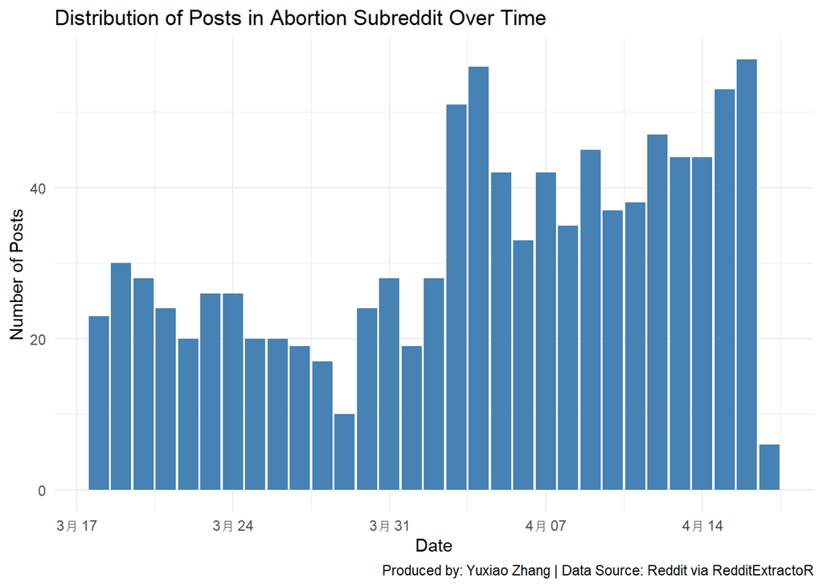

```r
abort_time <- top_abort_urls %>%
  mutate(date = date(date_utc)) %>%
  group_by(date) %>%
  summarise(count = n()) %>%
  ungroup()

p <- ggplot(abort_time, aes(x = date, y = count)) +
  geom_bar(stat = "identity", fill = "steelblue") +
  labs(title = "Distribution of Posts in Abortion Subreddit Over Time",
       x = "Date",
       y = "Number of Posts",
       caption = "Produced by: Yuxiao Zhang | Data Source: Reddit via RedditExtractoR") +
  theme_minimal()
print(p)
```